# Regression und Prädiktion

## 6.3 EDA [4 Punkte]

Wir haben bereits begonnen, mit diesen Daten zu arbeiten, aber wir sollten wirklich einen Schritt zurücktreten und uns eine Frage stellen. **Was sind diese Daten?** Wann immer Sie sich diese Frage stellen, sollten Sie sich die Daten “anschauen”. Man sollte drei Dinge tun:

- Lesen Sie die Metadaten, in diesem Fall die R-Dokumentation.
  - Woher kommen diese Daten?
  - Was ist eine Beobachtung in diesem Datensatz?
  - Was sind die Variablen in diesem Datensatz?
- Betrachten Sie die Daten in tabellarischer Form. Dies kann durch Anklicken des Datensatzes im RStudio Enviroment-Panel oder durch Verwendung des View() Befehls auf dem Datensatz erfolgen.
  - Was ist der Typ der einzelnen Variablen?
  - Sind kategorische Variablen als Faktoren kodiert?
- Stellen Sie die Daten dar (Plots).

**Beantworten Sie die ersten beiden Fragen!** 1) Die Daten sind tägliche Messungen der Luftqualität in New York von Mai bis September 1973. Sie wurden vom New York State Department of Conservation (Ozondaten) und vom National Weather Service (meteorologische Daten) bezogen. Das df hat 153 Beobachtungen und sechs Variablen: 1: Ozone  
2: Solar.R 3: Wind  
4: Temp  
5: Month  
6: Day

2. Im originalen Datensatz sind alle Spalten numerisch. Bei den ersten vier Variablen ist dies in Ordnung, doch die Tage und Monate sollten als Faktoren formatiert sein, da ansonsten keine korrekte Analyse des Datensatzes möglich ist (bspw. würde Dezember “besser” bewertet werden als der Januar, da 12 > 01)

**—-**

Erstellen Sie ein Diagramm, das alle möglichen Streudiagramme von zwei Variablen im Trainingsdatensatz zeigt.

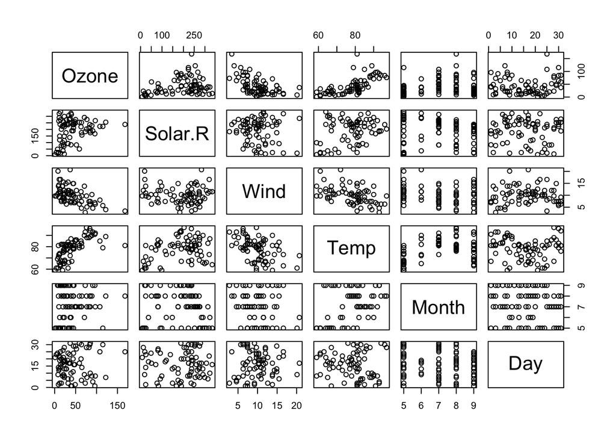

```r
plot(trn_data)
```

Da wir uns auf die Vorhersage von `Ozone` mit Hilfe von `Temp` konzentrieren werden, erstellen Sie eine Streudiagramm, das nur diese Beziehung anhand der Trainingsdaten zeigt

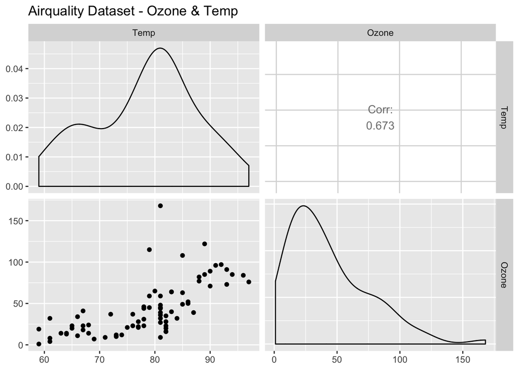

```r
ggpairs(trn_data, columns=c("Temp", "Ozone"), progress = F) + ggtitle("Airquality Dataset - Ozone & Temp")
```

## 6.4 Modelle [6 Punkte]

Passen Sie insgesamt fünf Polynommodelle an die Trainingsdaten an, die zur Vorhersage von Ozon aus Temp. verwendet werden können. Verwenden Sie Polynomgrade von 1 bis 5.

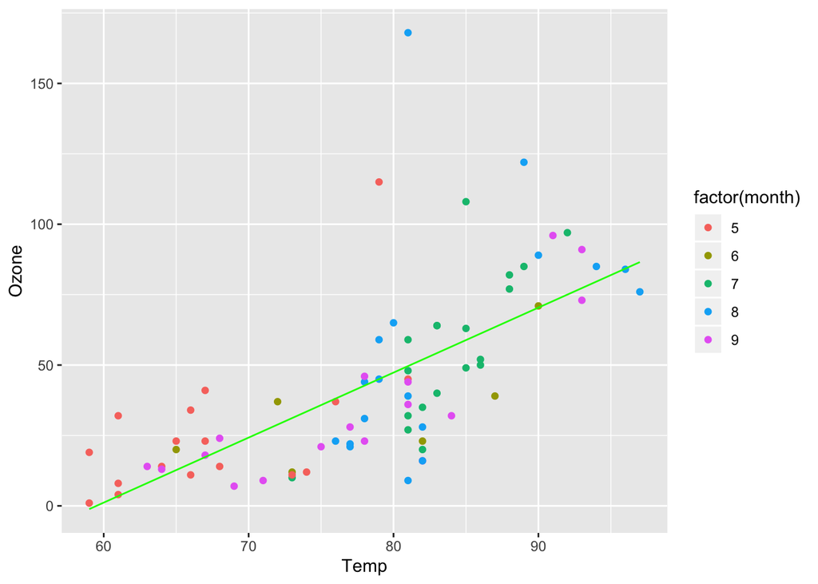

```r
# Lineares Model (Polynom grad 1)
month <- trn_data$Month
mod_1 <- lm(Ozone ~ poly(Temp, 1), data = trn_data)

df <- data.frame(Temp = trn_data$Temp, Ozone = trn_data$Ozone, mod_1 = mod_1$fitted.values)
ggplot(df, aes(x=Temp, y=Ozone, colour = factor(month))) + geom_point() + xlab("Temp") + ylab("Ozone") + geom_line(df, mapping = aes(x=Temp, y=mod_1), color="green")
```

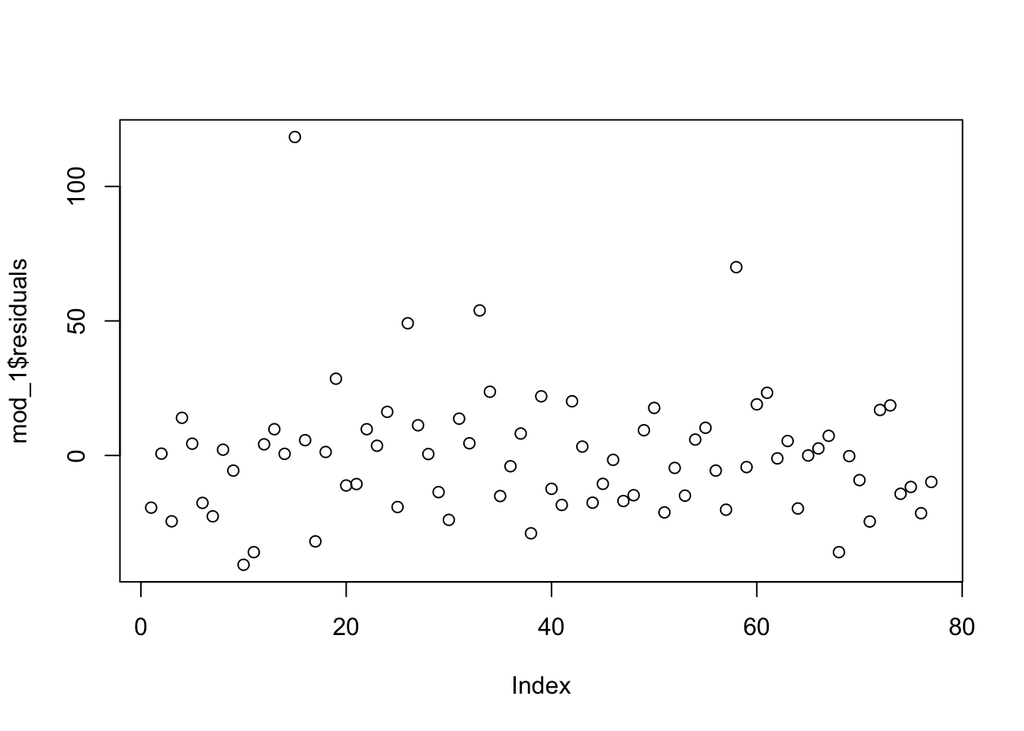

```r
# Interpretation des Outputs von R von Modell 1 (möglichst vollständig/relevant, Koeffizient(en),...)
plot(mod_1$residuals)
```

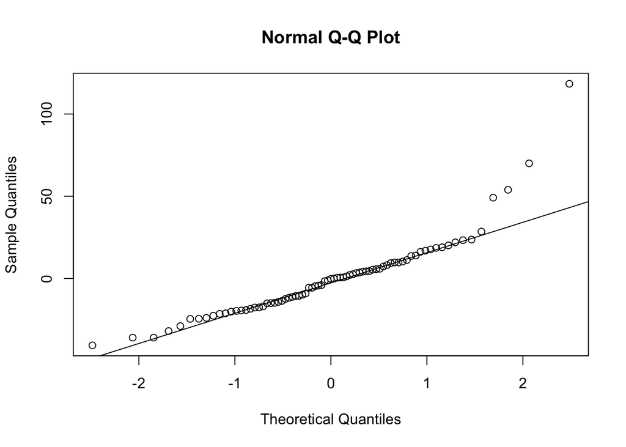

```r
qqnorm(mod_1$residuals)
qqline(mod_1$residuals)
```

```r
summary(mod_1)
```

```
##
## Call:
## lm(formula = Ozone ~ poly(Temp, 1), data = trn_data)
##
## Residuals:
##     Min      1Q  Median      3Q     Max
## -40.626 -15.087  -0.243   9.759 118.374
##
## Coefficients:
##               Estimate Std. Error t value Pr(>|t|)
## (Intercept)     43.182      2.756  15.665  < 2e-16 ***
## poly(Temp, 1)  190.514     24.188   7.876 2.05e-11 ***
## ---
## Signif. codes:  0 '***' 0.001 '**' 0.01 '*' 0.05 '.' 0.1 ' ' 1
##
## Residual standard error: 24.19 on 75 degrees of freedom
## Multiple R-squared:  0.4527, Adjusted R-squared:  0.4454
## F-statistic: 62.04 on 1 and 75 DF,  p-value: 2.051e-11
```

```r
# correlation
cor(y=mod_1$fitted.values, trn_data$Ozone, method = "pearson")
```

```
## [1] 0.6728296
```

```r
# Der Residienplot weißt keine besonderen Auffälligkeiten in der Verteilung der Residuen auf. Dies deutet darauf hin, dass die gefitteten Werte und die Residuen unkorreliert sind.
# Der QQ-Plot deutet auf eine Normalverteilung hin, auch wenn die Werte an den extremen weit von der Linie entfernt sind (Ausreißer / Messfehler).
# Der Korrelationskoeffizient deutet auf eine moderate, postive Korrelation zwischen Ozon und Temperatur hin.
# Der Residuen-Standard-Error liegt bei 24,19, r2 bei 0,4527, r bei 0,673. All diese Werte lassen vermuten, dass unser Modell nicht besonders gut performen wird.
```

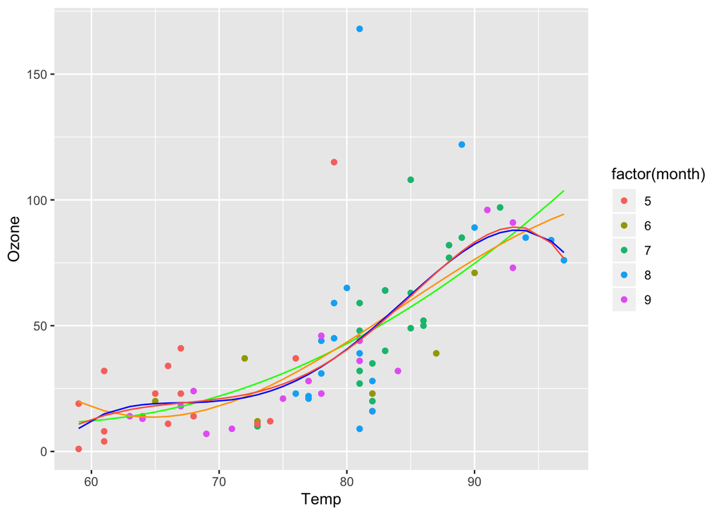

```r
mod_2 <- lm(Ozone ~ poly(Temp, 2), data = trn_data)
mod_3 <- lm(Ozone ~ poly(Temp, 3), data = trn_data)
mod_4 <- lm(Ozone ~ poly(Temp, 4), data = trn_data)
mod_5 <- lm(Ozone ~ poly(Temp, 5), data = trn_data)

df$mod_2 = mod_2$fitted.values
df$mod_3 = mod_3$fitted.values
df$mod_4 = mod_4$fitted.values
df$mod_5 = mod_5$fitted.values

ggplot(df, aes(x=Temp, y=Ozone, colour = factor(month))) + geom_point() + xlab("Temp") + ylab("Ozone") +
  geom_line(df, mapping = aes(x=Temp, y=mod_2), color="green") +
  geom_line(df, mapping = aes(x=Temp, y=mod_3), color="orange") +
  geom_line(df, mapping = aes(x=Temp, y=mod_4), color="blue") +
  geom_line(df, mapping = aes(x=Temp, y=mod_5), color="tomato")
```

Vorhersage von Ozon für eine Temperatur von 89 Grad Fahrenheit unter Verwendung des Polynommodells mit drei Graden.

```r
month <- trn_data$Month
predict_degree_3_89 <- predict(mod_3, data.frame(Temp = 89))
predict_degree_3_89
```

```
##        1
## 73.22423
```

```r
predict_degree_3_89.sol <- predict(mod_3, data.frame(Temp = 89)) #74.40082
predict_degree_3_89.sol
```

[output not shown]

Prädiktieren Sie alle 5 Modelle für Train/Test-Daten

```r
# Prediction
one_pred_train <- predict(mod_1, newdata = trn_data)
one_pred_tst <- predict(mod_1, newdata = tst_data)

two_pred_train <- predict(object = mod_2, newdata = trn_data)
two_pred_tst <- predict(object = mod_2, newdata = tst_data)

three_pred_train <- predict(object = mod_3, newdata = trn_data)
three_pred_tst <- predict(object = mod_3, newdata = tst_data)

four_pred_train <- predict(object = mod_4, newdata = trn_data)
four_pred_tst <- predict(object = mod_4, newdata = tst_data)

five_pred_train <- predict(object = mod_5, newdata = trn_data)
five_pred_tst <- predict(object = mod_5, newdata = tst_data)
```

## 6.5 KNN Modell [3 Punkte]

Verwenden Sie KNN mit `k = 5`, um Vorhersagen für jede der Beobachtungen sowohl im Train- als auch in den Testdatensätzen zu treffen. Speichern Sie die Ergebnisse in Vektoren mit den Namen `knn_pred_trn` und `knn_pred_tst`.

Dazu benötigen Sie die Funktion `knn.reg()` aus dem FNN-Paket. Die knn.reg() unterscheidet sich sehr von der Funktion lm(). Prüfen Sie die Dokumentation!

```r
knn_pred_trn = knn.reg(train = trn_data["Temp"], test = trn_data["Temp"], y = trn_data["Ozone"], k =  5)
knn_pred_tst = knn.reg(train = trn_data["Temp"], test = tst_data["Temp"], y = trn_data["Ozone"], k =  5)

# root mean squared error
sqrt(mean((trn_data$Ozone - knn_pred_trn$pred) ^ 2))
```

```
## [1] 20.67441
```

```r
sqrt(mean((tst_data$Ozone - knn_pred_tst$pred) ^ 2))
```

```
## [1] 21.06304
```

```r
# mean absolute error
mean(abs(trn_data$Ozone - knn_pred_trn$pred))
```

```
## [1] 12.98961
```

```r
mean(abs(tst_data$Ozone - knn_pred_tst$pred))
```

```
## [1] 14.16471
```

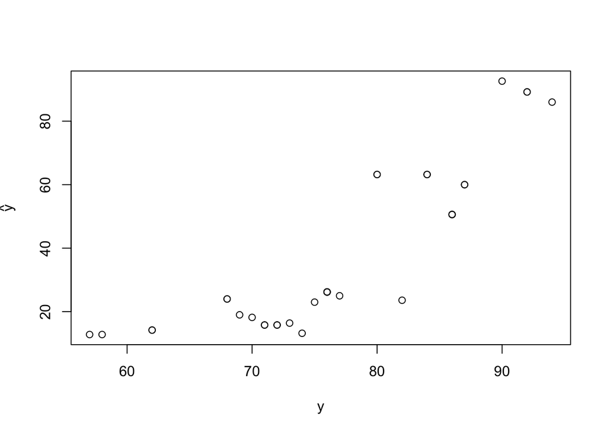

```r
plot(tst_data$Temp, knn_pred_tst$pred, xlab="y", ylab=expression(hat(y)))
```

## 6.6 Ergebnisse [3 Punkte]

Berechnen Sie sowohl den Trainings- als auch den Test-RMSE für die obigen Modelle unter Verwendung der von Ihnen gespeicherten Vorhersagen

```r
rmse_trn_1 <- calc_rmse(actual = trn_data$Ozone, predicted = one_pred_train)
rmse_tst_1 <- calc_rmse(actual = tst_data$Ozone, predicted = one_pred_tst)

# 1
rmse_trn_1
```

```
## [1] 23.87197
```

```r
rmse_tst_1
```

```
## [1] 23.4278
```

```r
rmse_trn_2 <- calc_rmse(actual = trn_data$Ozone, predicted = two_pred_train)
rmse_tst_2 <- calc_rmse(actual = tst_data$Ozone, predicted = two_pred_tst)

# 2
rmse_trn_2
```

```
## [1] 23.22314
```

```r
rmse_tst_2
```

```
## [1] 20.96126
```

```r
rmse_trn_3 <- calc_rmse(actual = trn_data$Ozone, predicted = three_pred_train)
rmse_tst_3 <- calc_rmse(actual = tst_data$Ozone, predicted = three_pred_tst)

# 3
rmse_trn_3
```

```
## [1] 23.04839
```

```r
rmse_tst_3
```

```
## [1] 20.80547
```

```r
rmse_trn_4 <- calc_rmse(actual = trn_data$Ozone, predicted = four_pred_train)
rmse_tst_4 <- calc_rmse(actual = tst_data$Ozone, predicted = four_pred_tst)

# 4
rmse_trn_4
```

```
## [1] 22.65551
```

```r
rmse_tst_4
```

```
## [1] 19.53752
```

```r
rmse_trn_5 <- calc_rmse(actual = trn_data$Ozone, predicted = five_pred_train)
rmse_tst_5 <- calc_rmse(actual = tst_data$Ozone, predicted = five_pred_tst)

# 5
rmse_trn_5
```

```
## [1] 22.64251
```

```r
rmse_tst_5
```

```
## [1] 19.4799
```

```r
# Knn
rmse_knn_trn <- calc_rmse(actual = trn_data$Ozone, predicted = knn_pred_trn$pred)
rmse_knn_tst <- calc_rmse(actual = tst_data$Ozone, predicted = knn_pred_tst$pred)

rmse_knn_trn
```

```
## [1] 20.67441
```

```r
rmse_knn_tst
```

```
## [1] 21.06304
```

Berechnen Sie die R2 Scores der Modelle

```r
r2_trn_1 <- summary(mod_1)$r.squared
r2_trn_2 <- summary(mod_2)$r.squared
r2_trn_3 <- summary(mod_3)$r.squared
r2_trn_4 <- summary(mod_4)$r.squared
r2_trn_5 <- summary(mod_5)$r.squared
r2_trn_Knn <- cor(knn_pred_trn$pred, trn_data$Ozone) ^ 2

r2_trn_1
```

```
## [1] 0.4526997
```

```r
r2_trn_2
```

```
## [1] 0.4820459
```

```r
r2_trn_3
```

```
## [1] 0.4898117
```

```r
r2_trn_4
```

```
## [1] 0.5070568
```

```r
r2_trn_5
```

```
## [1] 0.5076223
```

```r
r2_trn_Knn
```

```
## [1] 0.5985896
```

```r
#...
```

Erstellen Sie eine Tabelle, die die Ergebnisse der einzelnen Modellanpassungen zusammenfasst. (Die fünf Polynommodelle und das einzelne KNN-Modell.) Notieren Sie für jedes Modell den Modelltyp, den Wert des Abstimmparameters, den Train-RMSE und den Test-RMSE. (Betrachten Sie den Polynomgrad als Abstimmungsparameter.) Das Ergebnis sollte eine Tabelle mit einer Überschrift, sechs Zeilen und vier Spalten sein. Blenden Sie im endgültigen gerenderten Dokument den Code aus, der zur Erstellung der Tabelle verwendet wurde.

Hinweis: Erstellen Sie zuerst einen Datenrahmen und verwenden Sie dann die kable() Funktion aus dem knitr-Paket.

```r
# create a vector with the rmses of the training and test data wo we can plot them
trn_rmse_vector = c(
    rmse_trn_1,
    rmse_trn_2,
    rmse_trn_3,
    rmse_trn_4,
    rmse_trn_5,
    rmse_knn_trn
)
tst_rmses_vector = c(
    rmse_tst_1,
    rmse_tst_2,
    rmse_tst_3,
    rmse_tst_4,
    rmse_tst_5,
    rmse_knn_tst
)

# because table needs a data frame, we need to create it first
data = data.frame(
  method = c("poly", "poly", "poly", "poly", "poly", "knn"),
  tuning = c(1, 2, 3, 4, 5, 5),
  train  = c(trn_rmse_vector),
  test   = c(tst_rmses_vector)
)
colnames(data) = c("Modelltyp", "Abstimmparameter", "Train-RMSE", "Test-RMSE")
table <- kable(data, format = "html", digits = 2)
kable_styling(table, full_width = FALSE)
```

| Modelltyp | Abstimmparameter | Train-RMSE | Test-RMSE |
| --- | --- | --- | --- |
| poly | 1 | 23.87 | 23.43 |
| poly | 2 | 23.22 | 20.96 |
| poly | 3 | 23.05 | 20.81 |
| poly | 4 | 22.66 | 19.54 |
| poly | 5 | 22.64 | 19.48 |
| knn | 5 | 20.67 | 21.06 |

## 6.7 Plot der Ergebnisse [2 Punkte]

Stellen Sie die obige Streudiagramm von Ozon gegen die Temperaturform wieder her. Fügen Sie zu dieser Darstellung das Polynommodell hinzu, das am besten funktioniert hat, sowie das angepasste KNN-Modell. Können Sie diese Darstellung im gerenderten Dokument zentrieren? Blenden Sie den Code wieder aus, um die Darstellung zu erstellen.

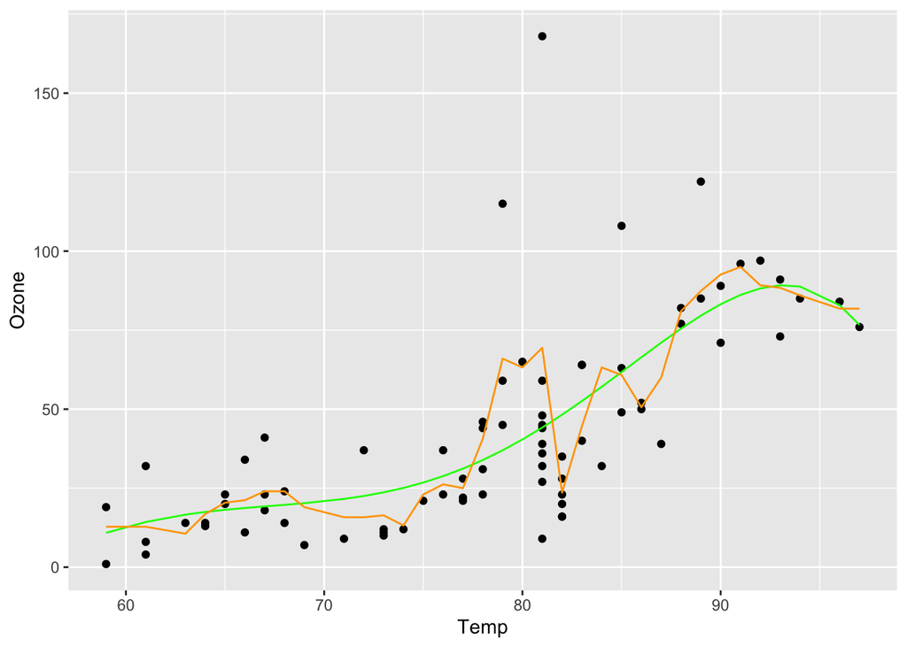

```r
ggplot() + geom_point(aes(x=Temp, y=Ozone ), data = trn_data) + xlab("Temp") + ylab("Ozone") +
  geom_line(aes(x=trn_data$Temp, y=five_pred_train), color="green") +
  geom_line(aes(x=trn_data$Temp, y=knn_pred_trn$pred), color="orange")
```

## 6.8 Multiple Prädiktoren [5 Punkte]

Bisher haben wir nur einen der verfügbaren Prädiktoren verwendet. Warum nicht alle verwenden? (Vielleicht sollten wir aber nur einige davon verwenden… Wir kommen später noch einmal auf diesen Gedanken zurück.)

[Übung] Fitten Sie ein additives lineares Modell mit Ozon als Antwort und den restlichen Variablen als Prädiktoren ein. Berechnen Sie den Test-RMSE für dieses Modell. Verbessert dies die vorherigen Modelle?

```r
mod_6 = lm(Ozone ~ ., data = trn_data)
prediction <- predict(mod_6, tst_data)
calc_rmse(actual = tst_data$Ozone, predicted = prediction)
```

```
## [1] 19.14013
```

```r
# Ja, dieses Modell ist mit einem RMSE von 19.14013 besser als alle anderen Modelle vorher. Das beste Modell vorher war das Modell poly 5 mit einem Test-RMSE von 19.48.
```